# EICA 2.0: A general theory of enemy release in plant invasions - Supplementary material

Richard D. Honor & Robert I. Colautti

#Setup

###**Load packages and colour palette**

```r
library(ggplot2) # plotting library

# Color blind friendly palette:
cbbPalette <- c("#000000", "#E69F00", "#56B4E9", "#009E73", "#F0E442", "#0072B2", "#D55E00", "#CC79A7")

#Main colours of graphs:
cbBlue<-"#56B4E9"#Blue colour
cbRed<-"#D55E00"#Red color
```

###**Plotting theme**

```r
#Create custum theme for plots

theme_simple<-function(){
  #base theme
  theme_classic() %+replace%
    #theme additions
  theme(

    #Remove legend
    legend.position="none",

    #Theme of axis text and ticks
    axis.text.x = element_blank(),
    axis.text.y = element_blank(),
    axis.ticks = element_blank(),

    #Theme of Axis titles
    axis.title.x =  element_text(color = "black", size = 20, face = "bold",margin=margin(10,0,0,0)),
    axis.title.y =  element_text(color = "black", size = 20, face = "bold",angle=0,vjust= 0.5,margin=margin(0,10,0,0)),

    #Plot Margin
    plot.margin = unit(c(1,1,1,1), "cm"),

    #Theme of Axis lines
    axis.line=element_line(colour = "black", size = 1)
  )
}
```

###**Custom variance function** This function calculates the variance between the output of 2 or more functions over a specified range of x values

```r
###Arguments:

#FunctionList: list of functions of interest
#xRange: range of x values to calulate variance
#yBelowZero: boolean to specify whether y values below zero should be treated as zero when calculating variance.

###Function:
VarCalc<-function(FunctionList,xRange,YBelowZero=FALSE){

  #Prep output vectors
  VarianceAtX<-c()
  outVector<-c()

  #for each x location.....
    for(i in 1:length(xRange)){

        #Each function calculate the y value
        for(j in 1:length(FunctionList)){
          out<-FunctionList[j][[1]](xRange[i])

            #This option will treat y values below 0 as 0 if YBelowZero=TRUE
            if(YBelowZero){
                if(out<0){
                  out<-0
                }
            }

          outVector[j]<-out#store all output from functions at that x location
        }

      VarianceAtX[i]<-var(outVector)#Calculate the variance for the data points at each x location and store in a vector.

    }
  return(VarianceAtX)
}
```

#Figures

###**Figure 1a.** Damage *vs.* enemy abundance

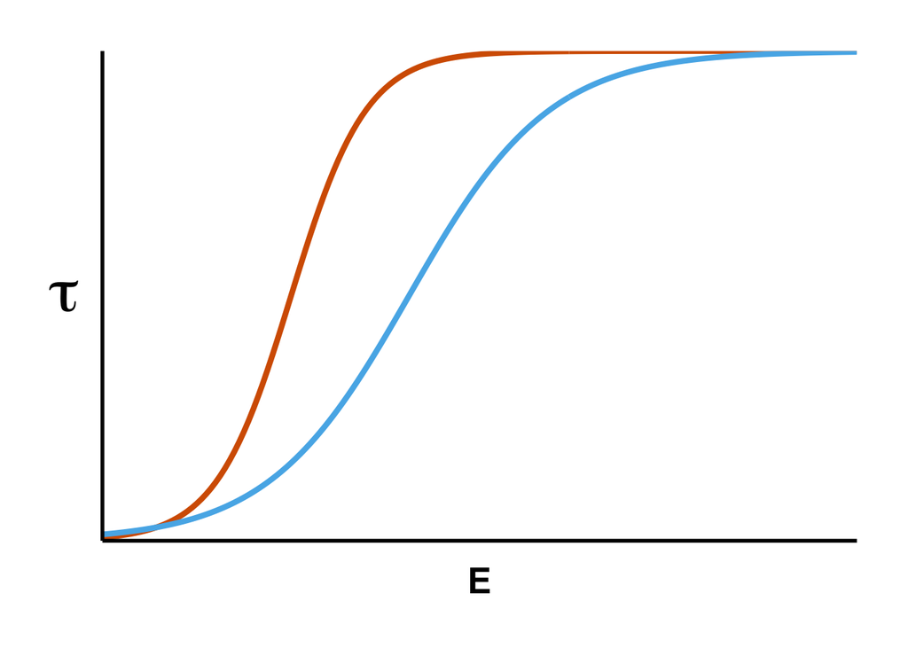

```r
######
##Logistic function generation----------------------
######

funcA<-function(x){plogis(x,40,8)} #redline
funcB<-function(x){plogis(x,65,15)} #blueline


######
##Visualization----------------------
######

xRange1a=0:160
yRangea<-funcA(xRange1a)
yRangeb<-funcB(xRange1a)

ggplot()+

    #Curves
    geom_path(aes(x=xRange1a,y=yRangea),colour=cbRed,size=1.5)+#redline
    geom_path(aes(x=xRange1a,y=yRangeb),colour=cbBlue,size=1.5)+#blueline

  #X
    scale_x_continuous(name="E", expand = expand_scale(0))+

      #y
      scale_y_continuous(name=bquote(tau), expand = expand_scale(0),limits=c(0,1))+

  # Plotting theme defined above
  theme_simple() +

  # Expand text for y-axis label
  theme(axis.title.y = element_text(size=36))
```

*Figure 1a.* Damage *vs.* enemy abundance for susceptible (red line) and tolerant genotypes (blue line).

###**Figure 1b.** Variance in damage *vs.* enemy abundance

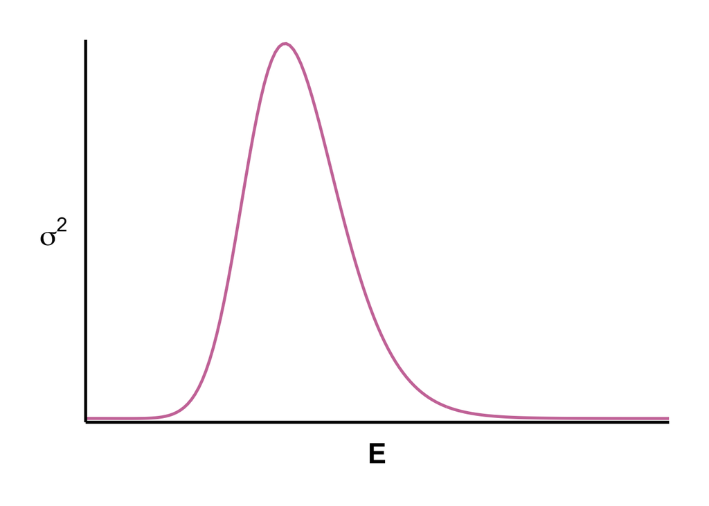

```r
######
#Get Variance Data--------------------------
######

funList<-list(funcA,funcB)#make the list with the functions I want variance data on
y<-VarCalc(funList,xRange1a)#input the list of functions with the desired x range.


######
##Visualization----------------------
######

ggplot()+

   #Variance Curve
    geom_path(aes(x=xRange1a,y=y),colour=cbbPalette[8],size=1)+

  #X
    scale_x_continuous(name="E", expand = expand_scale(0))+

      #y
      scale_y_continuous(name=bquote(sigma^2), expand = expand_scale(0.01))+

  # custom plotting theme, defined above
  theme_simple()
```

*Figure 1b.* Variance in damage between susceptible and tolerance genotypes along a gradient of enemy abundance.